# Homework #7 Math 160

Ethan Ashby

Due: 31 Mar, 2021

1. Create solutions using `:::: {.solution}` and `::::` in the .Rmd file.
2. If the .css file is not working for you, type out the Problem headings using `# Problem 1`, `# Solution`, `# Problem 2`, and so on.
3. Knit to an .html file.
4. Print out the .html file inside a browser (such as Chrome or Safari) to a .pdf file.
5. Upload the .pdf file to Gradescope.
6. Mark the pages that your questions are on.
7. Be sure to box your answers with the `\boxed{put in box}` $\LaTeX$ command.
8. Be sure to give nonintegral answers to four significant digits.

Suppose the target distribution is $g_X(s) = s^{-3 / 2} \mathbb{I}(s \geq 1)$. A slice sampler is used that works as follows given the current state $X$.

1. Draw $Y$ uniformly from 0 to $1 / X^{3 / 2}$.
2. Draw $X$ uniformly from 1 to $1 / Y^{2 / 3}$.

Implement this single step in R, then use it to take 1000 burn in steps followed by 1000 states of this chain, and use it to estimate $\mathbb{P}(X \geq 2)$. Replicate the chain run 10 times and report your result as $a \pm b$.

Step function

```r
step_splice_p1<-function(x){
  y<-runif(1)*1/x^(3/2)
  x<-runif(1, min=1, max=1/y^(2/3))
  return(x)
}
```

Mchain

```r
set.seed(1234567)
slice_sampler_p1<-function(steps){
  burnin<-steps
  datasteps<-steps
  x<-1
  for(i in 1:burnin){
    x<-step_splice_p1(x)
  }
  res<-rep(0, datasteps)
  for(i in 1:datasteps){
    res[i]<-(x>=2)
    x<-step_splice_p1(x)
  }
  return(res)
}

res<-replicate(10, mean(slice_sampler_p1(steps=1000)))

tibble(
  mean=mean(res),
  se=sd(res)/sqrt(length(res))
) %>% kable()
```

| mean | se |
| --- | --- |
| 0.6856 | 0.0118417 |

My estimate of $\mathbb{P}(X \geq 2)=\boxed{0.686 \pm 0.012}$.

Suppose the goal is to approximately sample $X$ with unnormalized density
$$g_X(x) = \sin(x) \cos(x)^2 \mathbb{I}(x \in [0, \tau / 4]).$$

Continuing the last problem, write R code to take steps in this Markov chain. Record the state during 1000 steps after 1000 steps of burn in, and plot a kernel density estimate of the result along with the true density for comparison.

This is the step function

```r
step_prod_slice_p3<-function(x, u){
  y1<-u[1]*sin(x)
  y2<-u[2]*cos(x)
  y3<-u[3]*cos(x)
  #lower bound
  lb<-asin(y1)
  ub<-min(acos(y2), acos(y3))
  x<-runif(1, min=lb, max=ub)
  return(x)
}
```

Below we run the Markov Chain. Using wolfram alpha, I found that the normalizing constant $C$ for $g_X(x)$ is $3$, so I compared the output of my Markov Chain to $3 \cdot g_X(x)$.

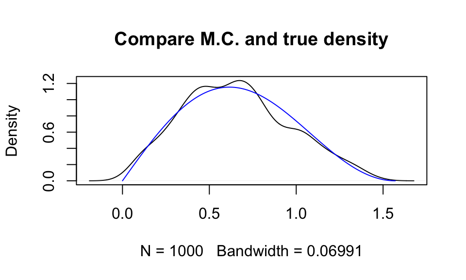

```r
set.seed(1234567)

prod_slice_mchain_p3<-function(steps){
  burnin<-steps
  datasteps<-steps
  m1<-replicate(3, runif(burnin))
  x<-1
  for(i in 1:burnin){
    x<-step_prod_slice_p3(x, u=m1[i,])
  }
  res<-rep(0, datasteps)
  m2<-replicate(3, runif(datasteps))
  for(i in 1:datasteps){
    x<-step_prod_slice_p3(x, u=m2[i,])
    res[i]<-x
  }
  return(res)
}

res<-prod_slice_mchain_p3(steps=1000)

true<-tibble(
  x=seq(0, (2*pi)/4, by=0.01),
  y=sin(x)*cos(x)*cos(x)
)

#markoc chain density
res %>% density() %>% plot(main="Compare M.C. and true density")
#true density
lines(x=true$x, y=3*true$y, col="blue")
```

The distribution produced by the markov chain (black) is quite close to the true density (blue). Increasing the number of steps leads to highly concordant distributions.

Consider the following edge values in the middle of a run of Swendsen-Wang.

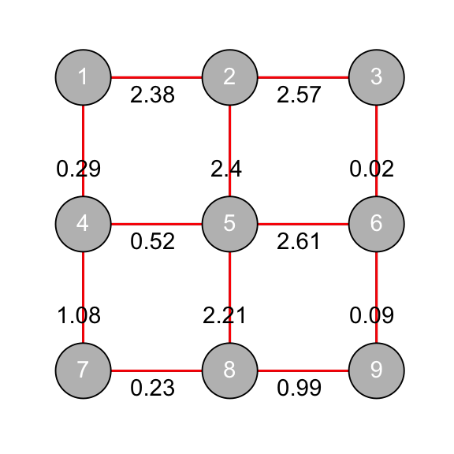

Suppose that $X \sim \textsf{Unif}([0, 5])$, and $M \sim \textsf{Unif}([-1, 1])$. Find analytically the probability that $X + M \in [0, 5]$.

Let’s first focus on the cases where $X+M$ is guaranteed to lie in $[0,5]$. If $X \in [1, 4]$, then $X+M$ is guaranteed to lie in $[0,5]$. The probability that $X \in [1,4]=\frac{m([1,4])}{m([0,5])}=\frac{3}{5}$. Now consider the case where $X \in [0,1)$. The expected value of $X$ in this region is $\mathbb{E}[X]=1/2$. For $X=1/2$, $X+M \in [0,5]$ with probability $3/4$. Thus, $3/4$ is the expected probability of remaining in $[0,5]$ if $X \in [0,1)$. The probability that $X \in [0,1)$ in the first place is $1/5$. The joint probability, of $X \in [0,1)$ AND $X+M \in [0,5]$ is $3/4 \cdot 1/5 = 3/20$. The same exact logic holds for $X \in (4,5]$. The expected probability of remaining in $[0,5]$ if $X \in (4,5]$ is $3/4$, and the probability of $X \in (4,5]$ in the first place is $1/5$. So the joint probability is $3/20$ as well. So the total probability of $X+M \in [0,5]$ is the sum of these probabilities: $3/5 + 3/20 + 3/20 = \boxed{9/10}$.

Write a Monte Carlo simulation to verify your answer in the previous problem.

```r
step_p6<-function(x, u){
  xnew<-x+(2*u-1)
  if(xnew<=5 & xnew>=0){
    return(xnew)
  }
  else{
    return(x)
  }
}
```

```r
set.seed(1234567)

p6_mchain<-function(steps){
  burnin<-steps
  datasteps<-steps
  m1<-runif(burnin)
  x<-3
  for(i in 1:burnin){
    x<-step_p6(x, m1[i])
  }
  res<-rep(0, datasteps)
  m2<-runif(datasteps)
  for(i in 1:datasteps){
    xnew<-step_p6(x, m2[i])
    #return if new state equals old state
    #i.e. if move was rejected b/c it would land outside state space
    res[i]<-(x!=xnew)
    x<-xnew
  }
  return(res)
}

res<-replicate(10, mean(p6_mchain(steps=1000)))

tibble(
  mean=mean(res),
  se=sd(res)/sqrt(10)
) %>% kable()
```

| mean | se |
| --- | --- |
| 0.9003 | 0.0049622 |

Using MC simulation, I estimated that the probability of $X+M \in [0,5]$ is $\boxed{0.9003 \pm 0.0050}$. This is very close to the analytical estimate!

For $\Omega = (-\infty, \infty)$, consider a symmetric random walk where $M \sim \textsf{Unif}([-1, 1])$, and the proposed state is $Y = X + M.$

Using this proposal together with $\textsf{M}\textsf{R}^2\textsf{T}^2$ to create R code for a single step in a chain with stationary distribution that has unnormalized density
$$f_X(s) = \exp(-|x|^{3 / 2}).$$
Your function should take as input the current state and a vector of two standard uniforms, and return the next state of the chain.

```r
mr2t2_step_p7<-function(x, m, u){
  y=x+m
  if(u <= exp(-abs(y)^(3/2))/exp(-abs(x)^(3/2))){
    return(y)
  }
  else{
    return(x)
  }
}
```

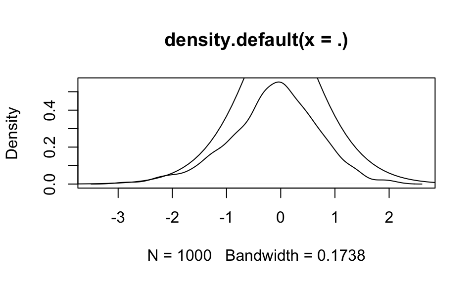

```r
set.seed(1234567)
run_chain_p7<-function(steps){
  burnin<-steps
  datasteps<-steps
  x<-0
  m1<-2*runif(burnin)-1
  m2<-runif(burnin)
  for(i in 1:burnin){
    x<-mr2t2_step_p7(x, m1[i], m2[i])
  }
  res<-rep(0, datasteps)
  m3<-2*runif(burnin)-1
  m4<-runif(burnin)
  for(i in 1:burnin){
    x<-mr2t2_step_p7(x, m3[i], m4[i])
    res[i]<-x
  }
  return(res)
}

true<-tibble(
  x=seq(-10, 10, by=0.1),
  y=exp(-abs(x)^(1.5))
)

run_chain_p7(steps=1000) %>% density() %>% plot()
lines(x=true$x, y=true$y)
```

For $\Omega = [0, 1]$, consider a symmetric random walk where $M \sim \textsf{Unif}([-0.1, 0.1])$, and the proposed state is $Y = X + M.$

Using this proposal together with $\textsf{M}\textsf{R}^2\textsf{T}^2$ to create R code for a single step in a chain with stationary distribution that has unnormalized density
$$f_X(s) = \sin(x)\cos(x)^2 \mathbb{I}(x\in[0,1]).$$

Run the chain for 1000 steps burnin and then take 1000 steps, recording the states visited. Use these to form a kernel density estimate of the distribution.

```r
mr2t2_step_p8<-function(x, m, u){
  y=x+m
  if(u <= (between(y, 0, 1))*(sin(y)*cos(y)*cos(y))/(sin(x)*cos(x)*cos(x)+(sin(x)==0))){
    return(y)
  }
  else{
    return(x)
  }
}
```

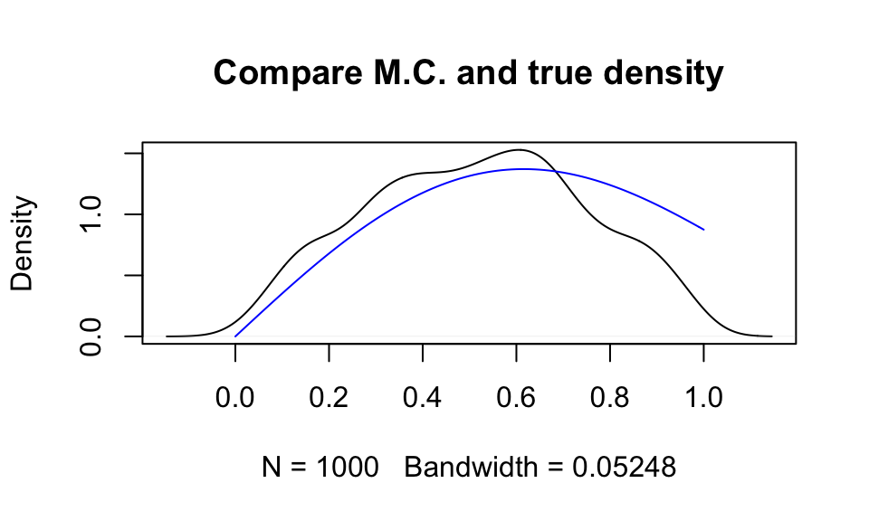

```r
set.seed(123456)

run_p8_mchain<-function(steps){
  burnin<-steps
  datasteps<-steps
  m1<-0.2*runif(burnin)-0.1
  m2<-runif(burnin)
  x<-0.5
  for(i in 1:burnin){
    x<-mr2t2_step_p8(x, m=m1[i], u=m2[i])
  }
  res<-rep(0, datasteps)
  m3<-0.2*runif(datasteps)-0.1
  m4<-runif(datasteps)
  for(i in 1:datasteps){
    x<-mr2t2_step_p8(x, m=m3[i], u=m4[i])
    res[i]<-x
  }
  return(res)
}

true<-tibble(
  x=seq(0, 1, by=0.01),
  y=sin(x)*cos(x)*cos(x)
)

res<-run_p8_mchain(steps=1000)

#markoc chain density
res %>% density() %>% plot(main="Compare M.C. and true density")
#true density
lines(x=true$x, y=3.5618*true$y, col="blue")
```

The kernel density estimate (black) is compared to the true density (blue). Normalizing constant for true density was estimated using Wolfram Alpha.

Continuing the last problem, suppose that the symmetric random walk is $M \sim \textsf{Unif}([-\epsilon, \epsilon]).$ Adjust $\epsilon$ so that the probability of accepting a move is with one percentage point of $1 / 4$.

```r
set.seed(123456)

run_p9_mchain<-function(steps, s){
  burnin<-steps
  datasteps<-steps
  m1<-2*s*runif(burnin)-s
  m2<-runif(burnin)
  x<-0.5
  for(i in 1:burnin){
    x<-mr2t2_step_p8(x, m=m1[i], u=m2[i])
  }
  res<-rep(0, datasteps)
  m3<-2*s*runif(datasteps)-s
  m4<-runif(datasteps)
  for(i in 1:datasteps){
    old_x<-x
    x<-mr2t2_step_p8(x, m=m3[i], u=m4[i])
    res[i]<-x != old_x
  }
  return(res)
}

res<-replicate(10, mean(run_p9_mchain(steps=1000, s=1.58)))

tibble(
  mean=mean(res),
  se=sd(res)/sqrt(length(res))
) %>% kable()
```

| mean | se |
| --- | --- |
| 0.2507 | 0.0040935 |

For $s=1.58$, the probability of acceptance is $\boxed{0.2507 \pm 0.0041}$.

Consider state space $\Omega = \{1, 2, \ldots\}$ where the proposed state is $Y = X + M$, where $M \sim \textsf{Unif}(\{-1, 1\})$.

Use $\textsf{M}\textsf{R}^2\textsf{T}^2$ together with this proposal to create a chain whose limiting distribution is
$$f_X(i) = \frac{C}{i^{3 / 2}} \mathbb{I}(i \in \{1, 2, 3, \ldots \}).$$

Run your chain with 10000 burnin and 10000 data gathering steps to estimate $\mathbb{P}(X = 1) = C$. Run your chain 10 times and report your estimate of $C$ as $a \pm b$.

```r
step_p10<-function(x, m, u){
  y<-x+m
  if(u <= ((y>=1)*x^(3/2)/(y^(3/2)+(y==0)))){
    return(y)
  }
  else{
    return(x)
  }
}
```

Note that since the target density is $f_X(i) = \frac{C}{i^{3 / 2}} \mathbb{I}(i \in \{1, 2, 3, \ldots \}).$, $f_X(i=1)=C$.

```r
set.seed(1234567)

run_mchain_10<-function(steps){
  burnin<-steps
  datasteps<-steps
  m1<-2*(runif(burnin)<0.5)-1
  m2<-runif(burnin)
  x<-2
  for(i in 1:burnin){
    x<-step_p10(x, m1[i], m2[i])
  }
  m3<-2*(runif(datasteps)<0.5)-1
  m4<-runif(datasteps)
  res<-rep(0, datasteps)
  for(i in 1:datasteps){
    x<-step_p10(x, m3[i], m4[i])
    res[i]<-x
  }
  return(res)
}

res<-replicate(10, mean(run_mchain_10(steps=10000)==1))
tibble(
  mean=mean(res),
  se=sd(res)/sqrt(10)
) %>% kable()
```

| mean | se |
| --- | --- |
| 0.35509 | 0.036242 |

Thus, my estimate for $C=\boxed{0.355 \pm 0.037}$.